# The Doppelganger Effect in Biomedical Data sets

# 1. Exploring the (Duchenne Muscular Dystrophy) DMD Datasets

## 0) Import packages

Some functions for pre-processing and analysis:

```r
# This function converts the probes to ensemble id
# df = df with the column "Probe"
#
convertProbesToEnsemble <- function(df, affy_attribute){
  if (!exists("ensembl")){
  ensembl <<- useEnsembl(biomart = "ensembl",
                    dataset = 'hsapiens_gene_ensembl')
  }
  if (!"Probe" %in% colnames(df)){
    print("The column 'Probe' is missing from df")
    return()
  }
  return_list = list()
  mapping_table =  select(ensembl,
                          keys= df$Probe,
                          columns= c(affy_attribute,
                                     "ensembl_gene_id"),
                          keytype= affy_attribute)
  return_list[["mapping_table"]] = mapping_table
  # Ensure the each affy attribute maps to only 1 ensemble id
  # (the smallest one)
  # (Ensure that affy->ensemble is a one-to-one mapping)
  mapping_table = mapping_table[
    order(mapping_table[[affy_attribute]],
          mapping_table[["ensembl_gene_id"]]),]
  mapping_table = mapping_table[!duplicated(
    mapping_table[[affy_attribute]]),]

  # Remove all probes with no corresponding ensemble id
  df = df[df$Probe %in% mapping_table[[affy_attribute]],]
  # Replace rownames with the ensemble gene id
  rownames(mapping_table) = mapping_table[[affy_attribute]]
  df$ensembl_ID = mapping_table[df$Probe,"ensembl_gene_id"]
  return_list[["before_dedup"]] = df
  df$Probe = NULL
  # ensure order of variables stay the same for checking purposes
  current_order = unique(df$ensembl_ID)
  # Get the median signal of probes with the same ensemble id
  df = aggregate(df[,-ncol(df)], by = list(df[,"ensembl_ID"]) , median)
  rownames(df) = df$Group.1
  df$Group.1 = NULL
  df = df[current_order, ]
  return_list[["returned_df"]] = df
  return(return_list)
}
# Integrates file loading, replacing probes with ensemble id and caching of cleaned_data
getDataFile<- function(filename, affy_attribute, batch_name){
  cleaned_filename = paste("cleaned_",filename, sep="")
  if (!file.exists(cleaned_filename)){
    temp_df = read.csv(filename)
    temp_df$PROT = NULL # Remove PROT column
    # Convert probes to ensemble ids
    conversion_results <<- convertProbesToEnsemble(
                                df = temp_df,
                                affy_attribute = affy_attribute)
    temp_df = conversion_results$returned_df
    # Add H to the end so that we can differentiate it later
    colnames(temp_df) = paste(colnames(temp_df), batch_name, sep = "_")
    write.csv(temp_df, cleaned_filename)
    return(temp_df)
  } else {
    temp_df = read.csv(cleaned_filename, row.names = 1)
    return(temp_df)
  }
}
# Generates meta data table from an existing dataframe (Assumes each row is a different patient)
getMetaDataDataframe <-function(df, batch_name){
  meta = data.frame(row.names = colnames(df))
  meta$Patient_ID = rownames(meta)
  meta$Batch = batch_name
  meta$Class = substr(meta$Patient_ID, 1, 3)
  return(meta)
}
dfSetDifference <- function(df1, df2){
  setdifference = c()
  for (i in 1:nrow(df1)){
    if (!any(df2$Sample1 == df1[i, "Sample1"] &
             df2$Sample2 == df1[i, "Sample2"])){
      setdifference = c(setdifference, i)
    }
  }
  return(df1[setdifference,])
}
getDoppelnNonDoppelSamples <- function(doppel_result, metadata, batchname){
  samples = unique(doppel_result$PPCC_df[doppel_result$PPCC_df$DoppelgangerLabel=="Doppelganger", "Sample1"])
  samples = c(samples, unique(doppel_result$PPCC_df[doppel_result$PPCC_df$DoppelgangerLabel=="Doppelganger", "Sample2"]))
  all_samples_of_batch = rownames(metadata[metadata$Batch==batchname,])
  doppel_samples = intersect(all_samples_of_batch, samples)
  non_doppel_samples = setdiff(all_samples_of_batch, doppel_samples)
  # Output in df form
  return_list = list(doppel_samples, non_doppel_samples)
  ## Compute maximum length
  max_length = max(sapply(return_list, length))
  ## Add NA values to list elements
  return_list = lapply(return_list, function(v) {
    c(v, rep(NA, max_length-length(v)))
    })
  # Column bind them
  return_df = do.call(cbind, return_list)
  colnames(return_df) = c("Doppelganger Samples", "Non-Doppelganger Samples")
  return(return_df)
}

# Oversample the raw and meta data automatically
oversample_batch <- function(raw_data, meta_data, seed=2021){
  return_list = list()
  # get batch sizes
  batch_sizes = table(meta_data$Batch)
  # Get number of samples to over sample
  add_num_samples = max(batch_sizes) - min(batch_sizes)
  # Get batch to over sample
  min_batch = names(which.min(batch_sizes))
  # Get min_batch sample names
  min_batch_samples = rownames(meta_data[meta_data$Batch==min_batch, ])
  # Over sample some samples
  set.seed(seed)
  if (add_num_samples < length(min_batch_samples)){
    new_sample_names = sample(min_batch_samples, add_num_samples,
                            replace = FALSE)
  }
  else {
    print("Error: This function does not support oversampling of over twice the smaller batch's size")
    return()
  }

  new_samples_meta = meta_data[new_sample_names, ]
  rownames(new_samples_meta) = paste(rownames(new_samples_meta), "dup", sep="_")
  return_list[["meta_data"]] = as.data.frame(rbind(meta_data,new_samples_meta))

  new_samples_raw = raw_data[, new_sample_names]
  colnames(new_samples_raw) = paste(colnames(new_samples_raw), "dup", sep="_")
  return_list[["raw_data"]] = as.data.frame(cbind(raw_data,new_samples_raw))

  return(return_list)
}

# Removes added duplicate samples and sample pairs
remove_all_dup <-function(doppel_result){
  doppel_return = doppel_result
  # Get column names with "_dup"
  duplicates = grep('_dup', colnames(doppel_return$Batch_corrected), value=TRUE)
  doppel_return$Batch_corrected = doppel_return$Batch_corrected[, !(colnames(doppel_return$Batch_corrected) %in% duplicates)]
  doppel_return$PPCC_matrix = doppel_return$PPCC_matrix[, !(colnames(doppel_return$PPCC_matrix) %in% duplicates)]
  doppel_return$PPCC_matrix = doppel_return$PPCC_matrix[!(rownames(doppel_return$PPCC_matrix) %in% duplicates),]
  doppel_return$PPCC_df = doppel_return$PPCC_df[!(doppel_return$PPCC_df$Sample1 %in% duplicates) & !(doppel_return$PPCC_df$Sample2 %in% duplicates), ]
  return(doppel_return)
}
```

## 1) Import the DMD datasets

HaslettData - 12 DMD Samples - 12 Normal Samples

```r
# Converts the affy probes to ensemble id
dmd_h = getDataFile(filename= "data/DMD-HaslettData.csv",
                    affy_attribute = "affy_hg_u95av2",
                    batch_name = "H")
#Forming The metadata dataframe
dmd_h_meta = getMetaDataDataframe(df = dmd_h, batch_name = "H")
```

PescatoriData - 22 DMD Samples - 14 Normal Samples

```r
dmd_p = getDataFile(filename = "data/DMD-PescatoriData.csv",
                    affy_attribute = "affy_hg_u133a",
                    batch_name = "P")

#Forming The metadata dataframe
dmd_p_meta = getMetaDataDataframe(df = dmd_p, batch_name = "P")
```

## 2) Identify doppelgangers within and between both batches

### a) Doppelgangers within HaslettData

22 Doppelgangers found within HaslettData.

```r
doppel_h = getPPCCDoppelgangers(dmd_h, dmd_h_meta)
```

```
[1] "1. No batch correction since there is only 1 batch..."
[1] "2. Calculating PPCC between samples of the same dataset..."

[1] "3. Labelling Sample Pairs according to their Class and Patient Similarities..."
[1] "4. Calculating PPCC cut off to identify PPCC data doppelgangers..."
[1] "5. Identifying PPCC data doppelgangers..."
```

```r
table(doppel_h$PPCC_df$DoppelgangerLabel)
```

```
    Doppelganger Not Doppelganger
              22              278
```

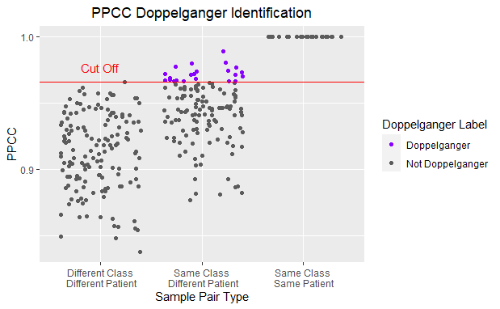

```r
visualisePPCCDoppelgangers(doppel_h)
```

### b) Doppelgangers within PescatoriData

There are 16 doppelgangers within PescatoriData.

```r
doppel_p = getPPCCDoppelgangers(dmd_p, dmd_p_meta)
```

```
[1] "1. No batch correction since there is only 1 batch..."
[1] "2. Calculating PPCC between samples of the same dataset..."

[1] "3. Labelling Sample Pairs according to their Class and Patient Similarities..."
[1] "4. Calculating PPCC cut off to identify PPCC data doppelgangers..."
[1] "5. Identifying PPCC data doppelgangers..."
```

```r
table(doppel_p$PPCC_df$DoppelgangerLabel)
```

```
    Doppelganger Not Doppelganger
              16              650
```

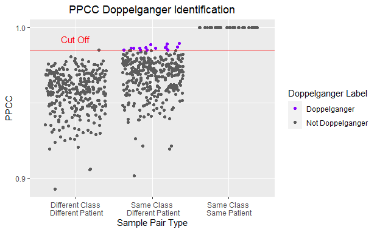

```r
visualisePPCCDoppelgangers(doppel_p)
```

### b) Doppelgangers Between Both Batches

Combining both data sets into one

```r
dmd_meta = data.frame(rbind(dmd_h_meta, dmd_p_meta))
#8813 variables in common
shared_variables_dmd = intersect(rownames(dmd_h), rownames(dmd_p))
dmd = data.frame(cbind(dmd_h[shared_variables_dmd, ],
                       dmd_p[shared_variables_dmd,]))
```

Finding doppelgangers between both datasets

```r
doppel_hp = getPPCCDoppelgangers(dmd, dmd_meta)
```

```
[1] "1. Batch correcting the 2 data sets with sva:ComBat..."
```

```
Found2batches
Adjusting for0covariate(s) or covariate level(s)
Standardizing Data across genes
Fitting L/S model and finding priors
Finding parametric adjustments
Adjusting the Data
```

```
[1] "2. Calculating PPCC between samples of each batch..."

[1] "3. Labelling Sample Pairs according to their Class and Patient Similarities..."
[1] "4. Calculating PPCC cut off to identify PPCC data doppelgangers..."
[1] "5. Identifying PPCC data doppelgangers..."
```

20 Doppelgangers between HaslettData and PescatoriData.

```r
table(doppel_hp$PPCC_df$DoppelgangerLabel)
```

```
    Doppelganger Not Doppelganger
              20              844
```

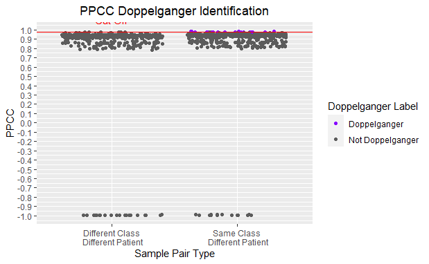

```r
visualisePPCCDoppelgangers(doppel_hp)
```

It seems that NOR_12_H is negatively correlated with all samples of batch P. This seems to be the result of NOR_12_H having abnormally low values and batch correction converting these low values to negative values.

```r
doppel_hp$PPCC_df[doppel_hp$PPCC_df$Sample1=="NOR_12_H" &
                    doppel_hp$PPCC_df$PPCC<0,]
```

|  | Sample1 | Sample2 | PPCC | ClassPatient | DoppelgangerLabel |
| --- | --- | --- | --- | --- | --- |
| 829 | NOR_12_H | DMD_1_P | -0.9915282 | Different Class\n Different Patient | Not Doppelganger |
| 830 | NOR_12_H | DMD_2_P | -0.9916888 | Different Class\n Different Patient | Not Doppelganger |
| 831 | NOR_12_H | DMD_3_P | -0.9934612 | Different Class\n Different Patient | Not Doppelganger |
| 832 | NOR_12_H | DMD_4_P | -0.9938980 | Different Class\n Different Patient | Not Doppelganger |
| 833 | NOR_12_H | DMD_5_P | -0.9930517 | Different Class\n Different Patient | Not Doppelganger |
| 834 | NOR_12_H | DMD_6_P | -0.9900323 | Different Class\n Different Patient | Not Doppelganger |
| 835 | NOR_12_H | DMD_7_P | -0.9931518 | Different Class\n Different Patient | Not Doppelganger |
| 836 | NOR_12_H | DMD_8_P | -0.9936086 | Different Class\n Different Patient | Not Doppelganger |
| 837 | NOR_12_H | DMD_9_P | -0.9931523 | Different Class\n Different Patient | Not Doppelganger |
| 838 | NOR_12_H | DMD_10_P | -0.9907831 | Different Class\n Different Patient | Not Doppelganger |

[output cut: 26 more lines]

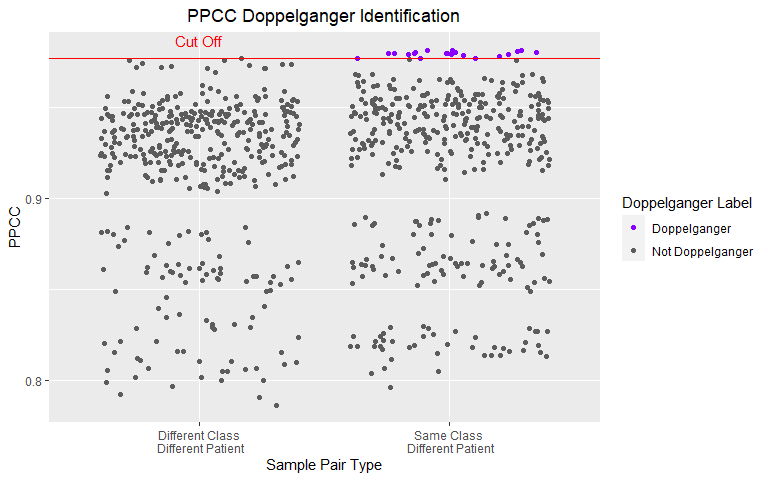

```r
doppel_hp_removed = doppel_hp
doppel_hp_removed$PPCC_df =
  doppel_hp_removed$PPCC_df[
    doppel_hp_removed$PPCC_df$Sample1!="NOR_12_H",]
visualisePPCCDoppelgangers(doppel_hp_removed)
```

## 3) Batch Effect on Doppelganger Identification

### a) With batch imbalances

The above results show the case where batch imbalances exist.

```r
table(dmd_meta$Batch)
```

```
 H  P
24 36
```

### b) Without batch imbalance

Here we will be oversampling the data set before doppelganger identification resolve batch imbalances.

```r
# Oversampling data
oversample = oversample_batch(dmd, dmd_meta)
dmd_over = oversample$raw_data
dmd_meta_over = oversample$meta_data
table(dmd_meta_over$Batch)
```

```
 H  P
36 36
```

```r
table( dmd_meta_over$Class, dmd_meta_over$Batch)
```

```
       H  P
  DMD 17 22
  NOR 19 14
```

```r
doppel_hp_over = getPPCCDoppelgangers(dmd_over, dmd_meta_over)
```

```
[1] "1. Batch correcting the 2 data sets with sva:ComBat..."
```

```
Found2batches
Adjusting for0covariate(s) or covariate level(s)
Standardizing Data across genes
Fitting L/S model and finding priors
Finding parametric adjustments
Adjusting the Data
```

```
[1] "2. Calculating PPCC between samples of each batch..."

[1] "3. Labelling Sample Pairs according to their Class and Patient Similarities..."
[1] "4. Calculating PPCC cut off to identify PPCC data doppelgangers..."
[1] "5. Identifying PPCC data doppelgangers..."
```

```r
# Remove excess sample pairs
doppel_hp_over = remove_all_dup(doppel_hp_over)
```

When there is an absence of batch imbalance, lesser doppelgangers were identified

```r
table(doppel_hp_over$PPCC_df$DoppelgangerLabel)
```

```
    Doppelganger Not Doppelganger
              19              845
```

One less pair was identified when batch imbalances were eliminated.

```r
dfSetDifference(
  doppel_hp$PPCC_df[doppel_hp$PPCC_df$DoppelgangerLabel=="Doppelganger", ],
  doppel_hp_over$PPCC_df[doppel_hp_over$PPCC_df$DoppelgangerLabel=="Doppelganger", ]
  )
```

|  | Sample1 | Sample2 | PPCC | ClassPatient | DoppelgangerLabel |
| --- | --- | --- | --- | --- | --- |
| 361 | DMD_11_H | DMD_1_P | 0.9766011 | Same Class\n Different Patient | Doppelganger |

The presence of batch imbalances decreased PPCC slightly in this case.

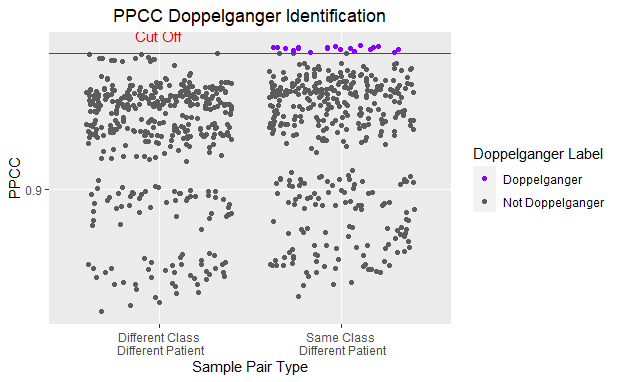

```r
doppel_hp_over_rem = doppel_hp_over
doppel_hp_over_rem$PPCC_df = doppel_hp_over_rem$PPCC_df[doppel_hp_over_rem$PPCC_df$Sample1!="NOR_12_H",]
visualisePPCCDoppelgangers(doppel_hp_over_rem)
```

```r
summary(doppel_hp$PPCC_df$PPCC)
```

```
   Min. 1st Qu.  Median    Mean 3rd Qu.    Max.
-0.9939  0.8767  0.9304  0.8366  0.9461  0.9812
```

```r
summary(doppel_hp_over$PPCC_df$PPCC)
```

```
   Min. 1st Qu.  Median    Mean 3rd Qu.    Max.
-0.9923  0.8992  0.9419  0.8512  0.9559  0.9830
```

With no batch imbalances, PPCC increased slightly.

### c) Batch imbalance on batch correction efficacy

```r
if (!"ggfortify" %in% installed.packages()){
  install.packages("ggfortify")
}
library(ggfortify)
```

#### Before Batch Correction

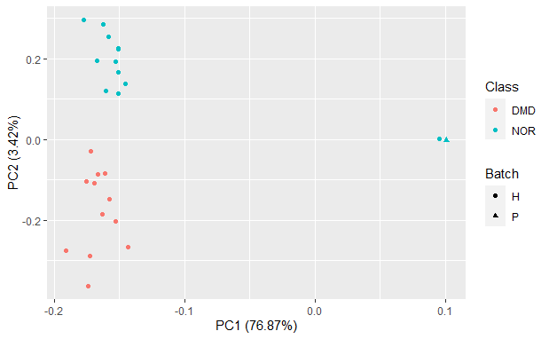

```r
pca_res = prcomp(t(dmd), scale. = TRUE)
autoplot(x=1, y=2, pca_res, data = dmd_meta, colour = 'Class', shape="Batch")
```

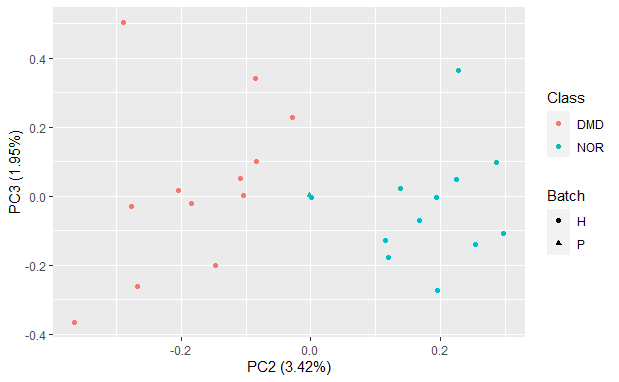

```r
autoplot(x=2, y=3, pca_res, data = dmd_meta, colour = 'Class', shape="Batch")
```

#### With batch imbalance

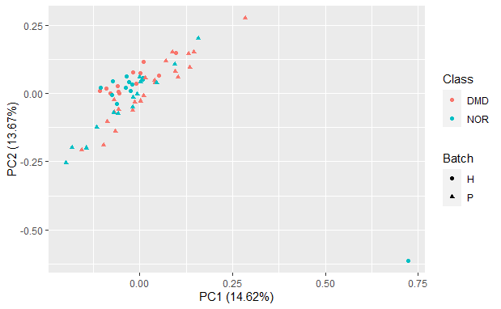

```r
pca_res = prcomp(t(doppel_hp$Batch_corrected), scale. = TRUE)
autoplot(x=1, y=2, pca_res, data = dmd_meta, colour = 'Class', shape="Batch")
```

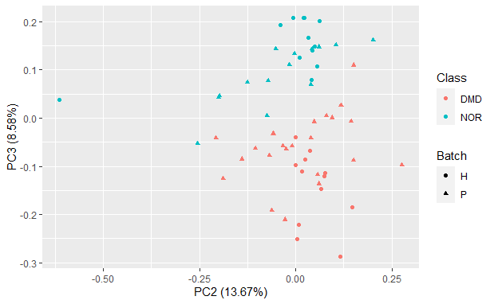

```r
autoplot(x=2, y=3, pca_res, data = dmd_meta, colour = 'Class', shape="Batch")
```

#### Without batch imbalance

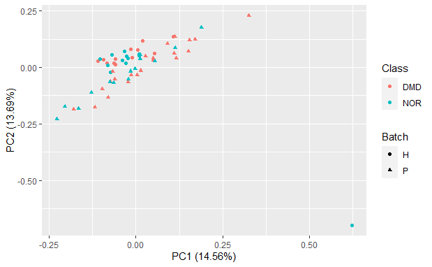

```r
pca_res = prcomp(t(doppel_hp_over$Batch_corrected), scale. = TRUE)
autoplot(x=1, y=2, pca_res, data = dmd_meta, colour = 'Class', shape="Batch")
```

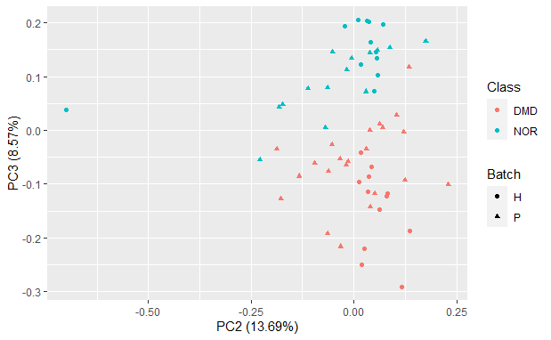

```r
autoplot(x=2, y=3, pca_res, data = dmd_meta, colour = 'Class', shape="Batch")
```

Output the doppelgangers for easier planning

```r
if (!"openxlsx" %in% installed.packages()){
  install.packages("openxlsx")
}
library(openxlsx)
wb = createWorkbook()
addWorksheet(wb, "MetaData")
addWorksheet(wb, "DoppelgangerPairs")
addWorksheet(wb, "ExtraPairs_Unbal-Bal")
addWorksheet(wb, "DoppelgangerSamplesH")
addWorksheet(wb, "DoppelgangerSamplesP")

writeData(wb, 1, dmd_meta)
writeData(wb, 2,
          doppel_hp_over$PPCC_df
          [doppel_hp_over$PPCC_df$DoppelgangerLabel=="Doppelganger",])
writeData(wb, 3, dfSetDifference(
  doppel_hp$PPCC_df
  [doppel_hp$PPCC_df$DoppelgangerLabel=="Doppelganger",],
  doppel_hp_over$PPCC_df
  [doppel_hp_over$PPCC_df$DoppelgangerLabel=="Doppelganger",]
  )
)
writeData(wb, 4, getDoppelnNonDoppelSamples(
  doppel_result = doppel_hp_over,
  metadata = dmd_meta,
  batchname = "H"))
writeData(wb, 5, getDoppelnNonDoppelSamples(
  doppel_result = doppel_hp_over,
  metadata = dmd_meta,
  batchname = "P"))
saveWorkbook(wb, file = "output/dmd_planning.xlsx", overwrite = TRUE)
```

## 4) Testing the Doppelganger Effect

```r
veri_results_dmd =  verifyDoppelgangers(
  "cleaned_data/dmd_experiment_plan.csv",
  doppel_hp_over$Batch_corrected,
  dmd_meta,
  do_batch_corr = FALSE,
  size_of_val_set = 6
  )
```

```
[1] "1. Preprocessing data..."
[1] "- Skip batch correction"
[1] "- Carrying out min-max normalisation"
[1] "2. Generating Feature Sets..."
[1] "3. Loading Experiment Plan..."
[1] "4. Training KNN models..."
```

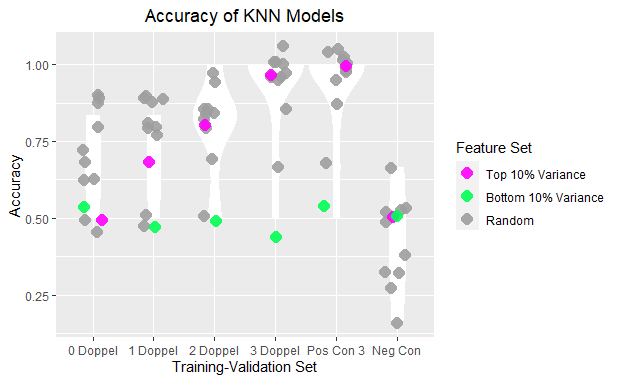

```r
originalTrainValidNames =  c("Doppel_0", "Doppel_1","Doppel_2","Doppel_3", "Pos_Con_3", "Neg_Con")

newTrainValidNames =  c("0 Doppel", "1 Doppel", "2 Doppel", "3 Doppel", "Pos Con 3", "Neg Con")

visualiseVerificationResults(veri_results_dmd,
                originalTrainValidNames,
                newTrainValidNames)
```

## Extra Analysis

Exploring PPCC values without batch correction

```r
temp = getPPCCDoppelgangers(dmd,
                            dmd_meta,
                            do_batch_corr = FALSE)
```

```
[1] "1. Skip batch correction"
[1] "2. Calculating PPCC between samples of each batch..."

[1] "3. Labelling Sample Pairs according to their Class and Patient Similarities..."
[1] "4. Calculating PPCC cut off to identify PPCC data doppelgangers..."
[1] "5. Identifying PPCC data doppelgangers..."
```

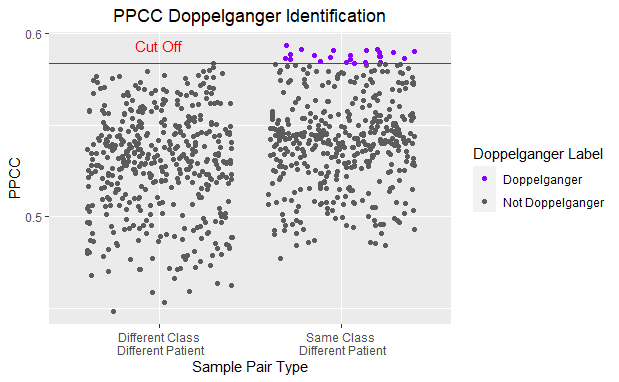

```r
visualisePPCCDoppelgangers(temp)
```

## Arrange plots

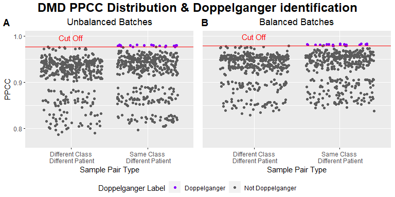

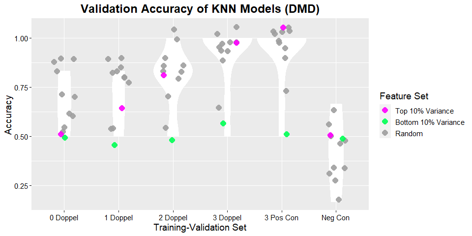